# IODS course project

### Bonus

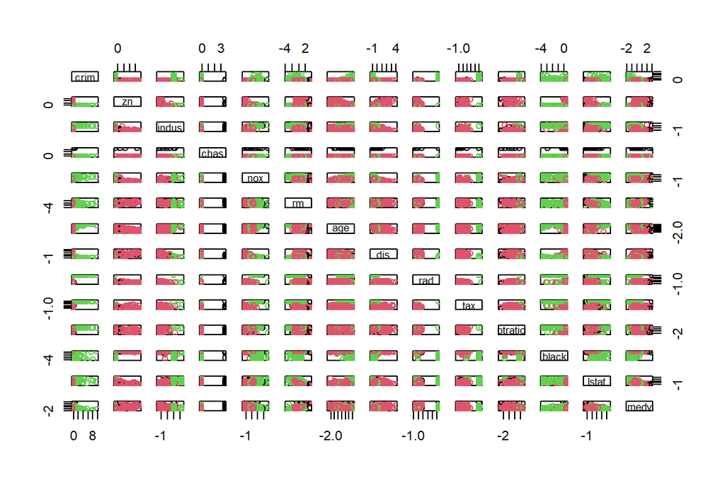

```r
library(MASS)
km2 <- kmeans(scaled_boston, centers = 3)
pairs(scaled_boston, col = km2$cluster)
```

```r
scaled_boston <- as.data.frame(scaled_boston)
lda.fit.1 <- lda(crim ~ ., data = scaled_boston)
```

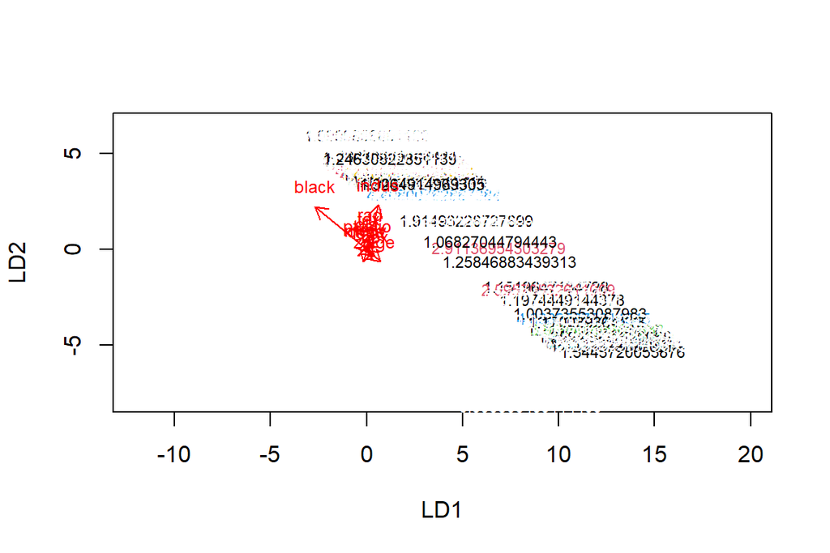

```r
plot(lda.fit.1, dimen = 2, col = as.numeric(scaled_boston$crim),
     pch = as.numeric(scaled_boston$crim))
lda.arrows(lda.fit.1, myscale = 1)
```

# Assignment 5

### Dimensionality reduction techniques

#### Data visualization and graphical presenttion

```r
#converting row names as the column name

human <- read.csv("data/human.csv")

library(tibble)
human_ <- column_to_rownames(human, "Country")

#Visualisation of human_ variables
library(GGally)
summary(human_)
```

```
##        X            Edu2.FM          Labo.FM          Life.Exp
##  Min.   :  1.0   Min.   :0.1717   Min.   :0.1857   Min.   :49.00
##  1st Qu.: 39.5   1st Qu.:0.7264   1st Qu.:0.5984   1st Qu.:66.30
##  Median : 78.0   Median :0.9375   Median :0.7535   Median :74.20
##  Mean   : 78.0   Mean   :0.8529   Mean   :0.7074   Mean   :71.65
##  3rd Qu.:116.5   3rd Qu.:0.9968   3rd Qu.:0.8535   3rd Qu.:77.25
##  Max.   :155.0   Max.   :1.4967   Max.   :1.0380   Max.   :83.50
##     Edu.Exp           GNI            Mat.Mor         Ado.Birth
##  Min.   : 5.40   Min.   :   581   Min.   :   1.0   Min.   :  0.60
##  1st Qu.:11.25   1st Qu.:  4198   1st Qu.:  11.5   1st Qu.: 12.65
##  Median :13.50   Median : 12040   Median :  49.0   Median : 33.60
##  Mean   :13.18   Mean   : 17628   Mean   : 149.1   Mean   : 47.16
##  3rd Qu.:15.20   3rd Qu.: 24512   3rd Qu.: 190.0   3rd Qu.: 71.95
##  Max.   :20.20   Max.   :123124   Max.   :1100.0   Max.   :204.80
##     Parli.F
##  Min.   : 0.00
##  1st Qu.:12.40
##  Median :19.30
##  Mean   :20.91
##  3rd Qu.:27.95
##  Max.   :57.50
```

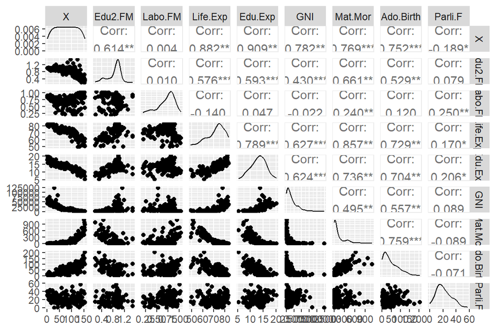

```r
ggpairs(human_, progress = FALSE)
```

From the summary of the human data, we can see that the scale of the variables differ largely from one to another. For example, the ratio of females and males education in seconder education ranges from 0.18 to 1.5 but the maternal mortality ratio ranges from 1.0 to 1100. Same is true for other variables. From the pair plots we can see the relationship of one variable to another, where many variables does not show any relationship with other, some shows positive relationship and other shows negative relationship. For example, Life.Exp and Edu.Exp, Mat.Mor and Ado.Birth showed positive relationship with each other. However, Life.Exp and Mat.Mor, Edu.Exp and Ado.Birth showed negative relationship. Some other variable also showed some non-linear relationship such as, GNI and Mat.Mor, GNI and Ado.Birth.

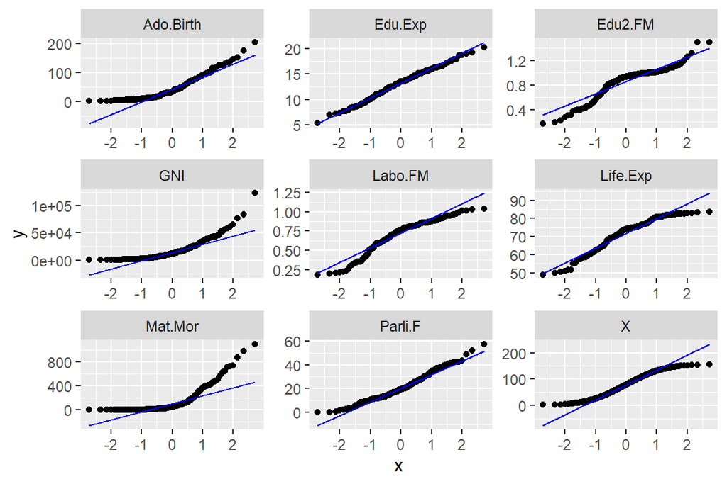

```r
library(tidyverse)
library(ggplot2)
human_ %>%
  gather() %>%
  ggplot(aes(sample=value)) +
  geom_qq() +
  geom_qq_line(colour = "blue") +
  facet_wrap('key', scales='free')
```

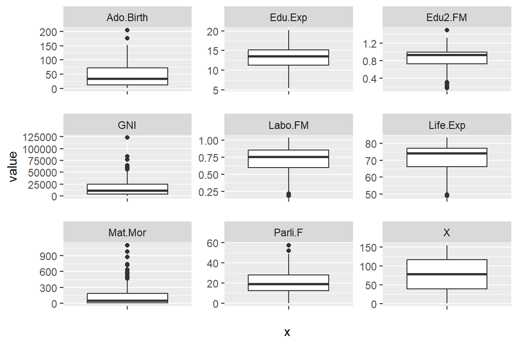

```r
human_ %>%
  gather() %>%
  ggplot(aes(y=value, x='')) +
  geom_boxplot() +
  facet_wrap('key', scales='free')
```

From the qqplot we can understand the normality of the variables, where it seems that except Edu.Exp and Parli.F, all other valriables are not normally distributed. From the box plot, it seems there are some outliers in Ado.Birth, GNI, Mat.Mor, Labo.FM, Parli.F and Edu.FM.

```r
# computing the correlation matrix and visualize it with corrplot
library(corrplot)
cor(human_)
```

```
##                      X      Edu2.FM      Labo.FM   Life.Exp     Edu.Exp
## X          1.000000000 -0.614119671  0.003517511 -0.8815567 -0.90921096
## Edu2.FM   -0.614119671  1.000000000  0.009564039  0.5760299  0.59325156
## Labo.FM    0.003517511  0.009564039  1.000000000 -0.1400125  0.04732183
## Life.Exp  -0.881556663  0.576029853 -0.140012504  1.0000000  0.78943917
## Edu.Exp   -0.909210961  0.593251562  0.047321827  0.7894392  1.00000000
## GNI       -0.781576170  0.430304846 -0.021739705  0.6266641  0.62433940
## Mat.Mor    0.768888352 -0.660931770  0.240461075 -0.8571684 -0.73570257
## Ado.Birth  0.752304598 -0.529418415  0.120158862 -0.7291774 -0.70356489
## Parli.F   -0.188511321  0.078635285  0.250232608  0.1700863  0.20608156
##                   GNI    Mat.Mor  Ado.Birth     Parli.F
## X         -0.78157617  0.7688884  0.7523046 -0.18851132
## Edu2.FM    0.43030485 -0.6609318 -0.5294184  0.07863528
## Labo.FM   -0.02173971  0.2404611  0.1201589  0.25023261
## Life.Exp   0.62666411 -0.8571684 -0.7291774  0.17008631
## Edu.Exp    0.62433940 -0.7357026 -0.7035649  0.20608156
## GNI        1.00000000 -0.4951623 -0.5565621  0.08920818
## Mat.Mor   -0.49516234  1.0000000  0.7586615 -0.08944000
## Ado.Birth -0.55656208  0.7586615  1.0000000 -0.07087810
## Parli.F    0.08920818 -0.0894400 -0.0708781  1.00000000
```

## principal component analysis (PCA) on the raw (non-standardized) human data

```r
# perform principal component analysis on the raw (non-standardized) human data
pca_human <- prcomp(human_)
pca_human_s <- summary(pca_human)
pca_human_s
```

```
## Importance of components:
##                              PC1      PC2   PC3   PC4   PC5   PC6   PC7    PC8
## Standard deviation     1.854e+04 186.5901 26.22 18.72 10.95 3.137 1.078 0.1888
## Proportion of Variance 9.999e-01   0.0001  0.00  0.00  0.00 0.000 0.000 0.0000
## Cumulative Proportion  9.999e-01   1.0000  1.00  1.00  1.00 1.000 1.000 1.0000
##                           PC9
## Standard deviation     0.1591
## Proportion of Variance 0.0000
## Cumulative Proportion  1.0000
```

```r
pca_human_pr <- round(1 * pca_human_s$importance[2,], digits = 5)

pca_human_pr
```

```
##    PC1    PC2    PC3    PC4    PC5    PC6    PC7    PC8    PC9
## 0.9999 0.0001 0.0000 0.0000 0.0000 0.0000 0.0000 0.0000 0.0000
```

```r
# create object pc_lab to be used as axis labels
paste0(names(pca_human_pr), " (", pca_human_pr, "%)")
```

```
## [1] "PC1 (0.9999%)" "PC2 (1e-04%)"  "PC3 (0%)"      "PC4 (0%)"
## [5] "PC5 (0%)"      "PC6 (0%)"      "PC7 (0%)"      "PC8 (0%)"
## [9] "PC9 (0%)"
```

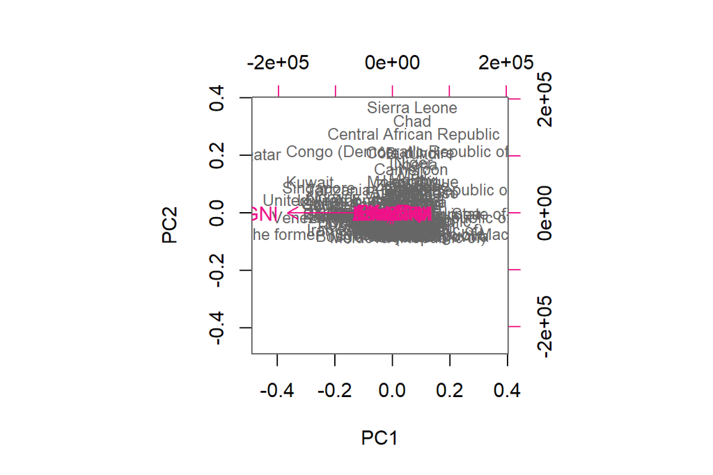

```r
# draw a biplot of the principal component representation and the original variables
biplot(pca_human, choices = 1:2, col = c("grey40", "deeppink2"), cex = c(0.8, 1))
```

## Standardizing the variables in human data

```
##        X              Edu2.FM           Labo.FM           Life.Exp
##  Min.   :-1.7154   Min.   :-2.8189   Min.   :-2.6247   Min.   :-2.7188
##  1st Qu.:-0.8577   1st Qu.:-0.5233   1st Qu.:-0.5484   1st Qu.:-0.6425
##  Median : 0.0000   Median : 0.3503   Median : 0.2316   Median : 0.3056
##  Mean   : 0.0000   Mean   : 0.0000   Mean   : 0.0000   Mean   : 0.0000
##  3rd Qu.: 0.8577   3rd Qu.: 0.5958   3rd Qu.: 0.7350   3rd Qu.: 0.6717
##  Max.   : 1.7154   Max.   : 2.6646   Max.   : 1.6632   Max.   : 1.4218
##     Edu.Exp             GNI             Mat.Mor          Ado.Birth
##  Min.   :-2.7378   Min.   :-0.9193   Min.   :-0.6992   Min.   :-1.1325
##  1st Qu.:-0.6782   1st Qu.:-0.7243   1st Qu.:-0.6496   1st Qu.:-0.8394
##  Median : 0.1140   Median :-0.3013   Median :-0.4726   Median :-0.3298
##  Mean   : 0.0000   Mean   : 0.0000   Mean   : 0.0000   Mean   : 0.0000
##  3rd Qu.: 0.7126   3rd Qu.: 0.3712   3rd Qu.: 0.1932   3rd Qu.: 0.6030
##  Max.   : 2.4730   Max.   : 5.6890   Max.   : 4.4899   Max.   : 3.8344
##     Parli.F
##  Min.   :-1.8203
##  1st Qu.:-0.7409
##  Median :-0.1403
##  Mean   : 0.0000
##  3rd Qu.: 0.6127
##  Max.   : 3.1850
```

```
## Importance of components:
##                           PC1    PC2     PC3     PC4     PC5    PC6     PC7
## Standard deviation     2.2770 1.1437 0.87751 0.79700 0.66196 0.5482 0.46456
## Proportion of Variance 0.5761 0.1453 0.08556 0.07058 0.04869 0.0334 0.02398
## Cumulative Proportion  0.5761 0.7214 0.80698 0.87756 0.92624 0.9596 0.98362
##                            PC8     PC9
## Standard deviation     0.32938 0.19731
## Proportion of Variance 0.01205 0.00433
## Cumulative Proportion  0.99567 1.00000
```

```
## [1] "PC1(0.58%)" "PC2(0.15%)" "PC3(0.09%)" "PC4(0.07%)" "PC5(0.05%)"
## [6] "PC6(0.03%)" "PC7(0.02%)" "PC8(0.01%)" "PC9(0%)"
```

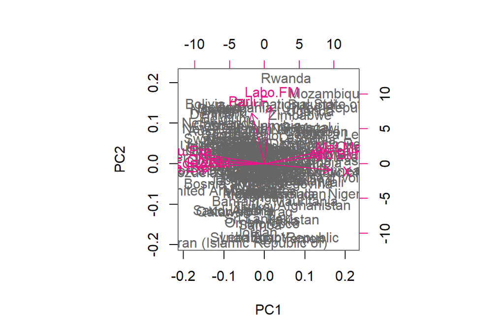

### Interpretation of biplot

A biplot is a way of visualizing the connections between two representations of the same data. First, a simple scatter plot is drawn where the observations are represented by two principal components (PC’s). Then, arrows are drawn to visualize the connections between the original variables and the PC’s. The following connections hold:

- The angle between the arrows can be interpreted as the correlation between the variables.
- The angle between a variable and a PC axis can be interpreted as the correlation between the two.
- The length of the arrows are proportional to the standard deviations of the variables.

## Tea data:

```r
#Reading tea data
library(readr)
library(tidyverse)
library(dplyr)
library(tidyr)
library(ggplot2)

tea <- read.csv("https://raw.githubusercontent.com/KimmoVehkalahti/Helsinki-Open-Data-Science/master/datasets/tea.csv", stringsAsFactors = TRUE)

# column names to keep in the dataset
keep_columns <- c("Tea", "How", "how", "sugar", "where", "lunch")

# select the 'keep_columns' to create a new dataset

tea_time <- dplyr::select(tea, all_of(keep_columns))

# look at the summaries and structure of the data
str(tea_time)
```

```
## 'data.frame':    300 obs. of  6 variables:
##  $ Tea  : Factor w/ 3 levels "black","Earl Grey",..: 1 1 2 2 2 2 2 1 2 1 ...
##  $ How  : Factor w/ 4 levels "alone","lemon",..: 1 3 1 1 1 1 1 3 3 1 ...
##  $ how  : Factor w/ 3 levels "tea bag","tea bag+unpackaged",..: 1 1 1 1 1 1 1 1 2 2 ...
##  $ sugar: Factor w/ 2 levels "No.sugar","sugar": 2 1 1 2 1 1 1 1 1 1 ...
##  $ where: Factor w/ 3 levels "chain store",..: 1 1 1 1 1 1 1 1 2 2 ...
##  $ lunch: Factor w/ 2 levels "lunch","Not.lunch": 2 2 2 2 2 2 2 2 2 2 ...
```

```r
summary(tea_time)
```

```
##         Tea         How                      how           sugar
##  black    : 74   alone:195   tea bag           :170   No.sugar:155
##  Earl Grey:193   lemon: 33   tea bag+unpackaged: 94   sugar   :145
##  green    : 33   milk : 63   unpackaged        : 36
##                  other:  9
##                   where           lunch
##  chain store         :192   lunch    : 44
##  chain store+tea shop: 78   Not.lunch:256
##  tea shop            : 30
##
```

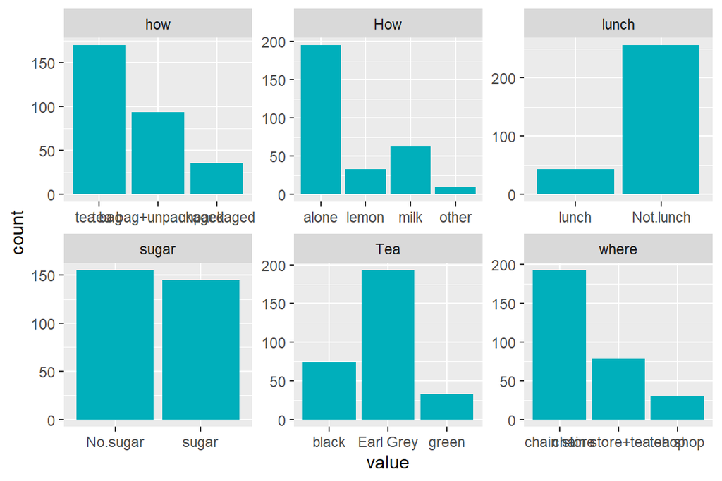

```r
# visualize the dataset
library(ggplot2)
pivot_longer(tea_time, cols = everything()) %>%
  ggplot(aes(value)) + geom_bar(fill = "#00AFBB")+facet_wrap("name", scales = "free")
```

From the tea I have selected six variables those are related to tea drinking behaviour. Here all the variables are categorical variables with multiple levels. From the bar plot of six variables we can see that the highest number of people use tea bag, people mostly consume raw tea compared to the use of tea with lemon, milk and other. The large number people drink tea during Not.lunch time, there is not much variation of using sugar and non sugar tea. The use of Earl Grey tea is highest and highest number of people still buy tea from the chain shop.

### Multiple Correspondence Analysis (MCA)

```
##
## Call:
## MCA(X = tea_time, graph = FALSE)
##
##
## Eigenvalues
##                        Dim.1   Dim.2   Dim.3   Dim.4   Dim.5   Dim.6   Dim.7
## Variance               0.279   0.261   0.219   0.189   0.177   0.156   0.144
## % of var.             15.238  14.232  11.964  10.333   9.667   8.519   7.841
## Cumulative % of var.  15.238  29.471  41.435  51.768  61.434  69.953  77.794
##                        Dim.8   Dim.9  Dim.10  Dim.11
## Variance               0.141   0.117   0.087   0.062
## % of var.              7.705   6.392   4.724   3.385
## Cumulative % of var.  85.500  91.891  96.615 100.000
##
## Individuals (the 10 first)
##                       Dim.1    ctr   cos2    Dim.2    ctr   cos2    Dim.3
## 1                  | -0.298  0.106  0.086 | -0.328  0.137  0.105 | -0.327
## 2                  | -0.237  0.067  0.036 | -0.136  0.024  0.012 | -0.695
## 3                  | -0.369  0.162  0.231 | -0.300  0.115  0.153 | -0.202
## 4                  | -0.530  0.335  0.460 | -0.318  0.129  0.166 |  0.211
## 5                  | -0.369  0.162  0.231 | -0.300  0.115  0.153 | -0.202
## 6                  | -0.369  0.162  0.231 | -0.300  0.115  0.153 | -0.202
## 7                  | -0.369  0.162  0.231 | -0.300  0.115  0.153 | -0.202
## 8                  | -0.237  0.067  0.036 | -0.136  0.024  0.012 | -0.695
## 9                  |  0.143  0.024  0.012 |  0.871  0.969  0.435 | -0.067
## 10                 |  0.476  0.271  0.140 |  0.687  0.604  0.291 | -0.650
##                       ctr   cos2
## 1                   0.163  0.104 |
## 2                   0.735  0.314 |
## 3                   0.062  0.069 |
## 4                   0.068  0.073 |
## 5                   0.062  0.069 |
## 6                   0.062  0.069 |
## 7                   0.062  0.069 |
## 8                   0.735  0.314 |
## 9                   0.007  0.003 |
## 10                  0.643  0.261 |
##
## Categories (the 10 first)
```

[output cut: 16 more lines]

```
## lemon                3.226 |   1.329  14.771   0.218   8.081 |
## milk                 2.422 |   0.013   0.003   0.000   0.116 |
## other                5.534 |  -2.524  14.526   0.197  -7.676 |
## tea bag             -6.941 |  -0.065   0.183   0.006  -1.287 |
## tea bag+unpackaged  11.956 |   0.019   0.009   0.000   0.226 |
## unpackaged          -6.482 |   0.257   0.602   0.009   1.640 |
##
## Categorical variables (eta2)
##                      Dim.1 Dim.2 Dim.3
## Tea                | 0.126 0.108 0.410 |
## How                | 0.076 0.190 0.394 |
## how                | 0.708 0.522 0.010 |
## sugar              | 0.065 0.001 0.336 |
## where              | 0.702 0.681 0.055 |
## lunch              | 0.000 0.064 0.111 |
```

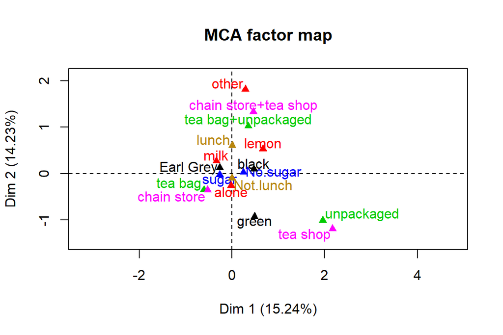

MCA is a method to analyze qualitative data and it is an extension of Correspondence analysis (CA). MCA can be used to detect patterns or structure in the data as well as in dimension reduction.

Explanation: Dim.1 = coordinate value of the first axis ctr = contribution to the construction of axis cos2 = quality of representation followed by the squared cosine v.test = test statistics v.test < -2 => the coordinate of the category is significantly less than 0 v.test > 2 => the coordinate of the category is significantly greater than 0 Categorical variables (eta2) = correlation ratio of each variable

# Assignment 6

## Analysis of longitudal data

### Data wrangling

```
##  [1] "treatment" "subject"   "week0"     "week1"     "week2"     "week3"
##  [7] "week4"     "week5"     "week6"     "week7"     "week8"
```

```
## 'data.frame':    40 obs. of  11 variables:
##  $ treatment: int  1 1 1 1 1 1 1 1 1 1 ...
##  $ subject  : int  1 2 3 4 5 6 7 8 9 10 ...
##  $ week0    : int  42 58 54 55 72 48 71 30 41 57 ...
##  $ week1    : int  36 68 55 77 75 43 61 36 43 51 ...
##  $ week2    : int  36 61 41 49 72 41 47 38 39 51 ...
##  $ week3    : int  43 55 38 54 65 38 30 38 35 55 ...
##  $ week4    : int  41 43 43 56 50 36 27 31 28 53 ...
##  $ week5    : int  40 34 28 50 39 29 40 26 22 43 ...
##  $ week6    : int  38 28 29 47 32 33 30 26 20 43 ...
##  $ week7    : int  47 28 25 42 38 27 31 25 23 39 ...
##  $ week8    : int  51 28 24 46 32 25 31 24 21 32 ...
```

```
##    treatment      subject          week0           week1           week2
##  Min.   :1.0   Min.   : 1.00   Min.   :24.00   Min.   :23.00   Min.   :26.0
##  1st Qu.:1.0   1st Qu.: 5.75   1st Qu.:38.00   1st Qu.:35.00   1st Qu.:32.0
##  Median :1.5   Median :10.50   Median :46.00   Median :41.00   Median :38.0
##  Mean   :1.5   Mean   :10.50   Mean   :48.00   Mean   :46.33   Mean   :41.7
##  3rd Qu.:2.0   3rd Qu.:15.25   3rd Qu.:58.25   3rd Qu.:54.25   3rd Qu.:49.0
##  Max.   :2.0   Max.   :20.00   Max.   :78.00   Max.   :95.00   Max.   :75.0
##      week3           week4           week5           week6           week7
##  Min.   :24.00   Min.   :20.00   Min.   :20.00   Min.   :19.00   Min.   :18.0
##  1st Qu.:29.75   1st Qu.:28.00   1st Qu.:26.00   1st Qu.:22.75   1st Qu.:23.0
##  Median :36.50   Median :34.50   Median :30.50   Median :28.50   Median :30.0
##  Mean   :39.15   Mean   :36.35   Mean   :32.55   Mean   :31.23   Mean   :32.2
##  3rd Qu.:44.50   3rd Qu.:43.00   3rd Qu.:38.00   3rd Qu.:37.00   3rd Qu.:38.0
##  Max.   :76.00   Max.   :66.00   Max.   :64.00   Max.   :64.00   Max.   :62.0
##      week8
##  Min.   :20.00
##  1st Qu.:22.75
##  Median :28.00
##  Mean   :31.43
##  3rd Qu.:35.25
##  Max.   :75.00
```

In BPRS data set, 40 male subjects were randomly assigned to one of two treatment groups and each subject was rated on the brief psychiatric rating scale (BPRS) measured before treatment began (week 0) and then at weekly intervals for eight weeks. The measurement has been taken repeatedly in each week from the same male subject. The BPRS assesses the level of 18 symptom constructs such as hostility, suspiciousness, hallucinations and grandiosity; each of these is rated from one (not present) to seven (extremely severe). The scale is used to evaluate patients suspected of having schizophrenia.In this data set all the variables are in integer form. In summary, we can see the mean and meadian of treatment effect from week 0 to 8.

```
##  [1] "ID"    "Group" "WD1"   "WD8"   "WD15"  "WD22"  "WD29"  "WD36"  "WD43"
## [10] "WD44"  "WD50"  "WD57"  "WD64"
```

```
## 'data.frame':    16 obs. of  13 variables:
##  $ ID   : int  1 2 3 4 5 6 7 8 9 10 ...
##  $ Group: int  1 1 1 1 1 1 1 1 2 2 ...
##  $ WD1  : int  240 225 245 260 255 260 275 245 410 405 ...
##  $ WD8  : int  250 230 250 255 260 265 275 255 415 420 ...
##  $ WD15 : int  255 230 250 255 255 270 260 260 425 430 ...
##  $ WD22 : int  260 232 255 265 270 275 270 268 428 440 ...
##  $ WD29 : int  262 240 262 265 270 275 273 270 438 448 ...
##  $ WD36 : int  258 240 265 268 273 277 274 265 443 460 ...
##  $ WD43 : int  266 243 267 270 274 278 276 265 442 458 ...
##  $ WD44 : int  266 244 267 272 273 278 271 267 446 464 ...
##  $ WD50 : int  265 238 264 274 276 284 282 273 456 475 ...
##  $ WD57 : int  272 247 268 273 278 279 281 274 468 484 ...
##  $ WD64 : int  278 245 269 275 280 281 284 278 478 496 ...
```

```
##        ID            Group           WD1             WD8             WD15
##  Min.   : 1.00   Min.   :1.00   Min.   :225.0   Min.   :230.0   Min.   :230.0
##  1st Qu.: 4.75   1st Qu.:1.00   1st Qu.:252.5   1st Qu.:255.0   1st Qu.:255.0
##  Median : 8.50   Median :1.50   Median :340.0   Median :345.0   Median :347.5
##  Mean   : 8.50   Mean   :1.75   Mean   :365.9   Mean   :369.1   Mean   :372.5
##  3rd Qu.:12.25   3rd Qu.:2.25   3rd Qu.:480.0   3rd Qu.:476.2   3rd Qu.:486.2
##  Max.   :16.00   Max.   :3.00   Max.   :555.0   Max.   :560.0   Max.   :565.0
##       WD22            WD29            WD36            WD43
##  Min.   :232.0   Min.   :240.0   Min.   :240.0   Min.   :243.0
##  1st Qu.:267.2   1st Qu.:268.8   1st Qu.:267.2   1st Qu.:269.2
##  Median :351.5   Median :356.5   Median :360.0   Median :360.0
##  Mean   :379.2   Mean   :383.9   Mean   :387.0   Mean   :386.0
##  3rd Qu.:492.5   3rd Qu.:497.8   3rd Qu.:504.2   3rd Qu.:501.0
##  Max.   :580.0   Max.   :590.0   Max.   :597.0   Max.   :595.0
##       WD44            WD50            WD57            WD64
##  Min.   :244.0   Min.   :238.0   Min.   :247.0   Min.   :245.0
##  1st Qu.:270.0   1st Qu.:273.8   1st Qu.:273.8   1st Qu.:278.0
##  Median :362.0   Median :370.0   Median :373.5   Median :378.0
##  Mean   :388.3   Mean   :394.6   Mean   :398.6   Mean   :404.1
##  3rd Qu.:510.5   3rd Qu.:516.0   3rd Qu.:524.5   3rd Qu.:530.8
##  Max.   :595.0   Max.   :612.0   Max.   :618.0   Max.   :628.0
```

RATS data from a nutrition study conducted in three groups of rats. The three groups were put on different diets, and each animal’s body weight (grams) was recorded repeatedly (approximately weekly, except in week seven when two recordings were taken) over a 9-week period. The question of most interest is whether the growth profiles of the three groups differ with different diet.In this data set there are 16 observations and 13 variables, all the variables are in integer formate.

```
## Rows: 360
## Columns: 5
## $ treatment <fct> 1, 1, 1, 1, 1, 1, 1, 1, 1, 1, 1, 1, 1, 1, 1, 1, 1, 1, 1, 1, …
## $ subject   <fct> 1, 2, 3, 4, 5, 6, 7, 8, 9, 10, 11, 12, 13, 14, 15, 16, 17, 1…
## $ weeks     <chr> "week0", "week0", "week0", "week0", "week0", "week0", "week0…
## $ bprs      <int> 42, 58, 54, 55, 72, 48, 71, 30, 41, 57, 30, 55, 36, 38, 66, …
## $ week      <int> 0, 0, 0, 0, 0, 0, 0, 0, 0, 0, 0, 0, 0, 0, 0, 0, 0, 0, 0, 0, …
```

```
## Rows: 176
## Columns: 5
## $ ID     <fct> 1, 2, 3, 4, 5, 6, 7, 8, 9, 10, 11, 12, 13, 14, 15, 16, 1, 2, 3,…
## $ Group  <fct> 1, 1, 1, 1, 1, 1, 1, 1, 2, 2, 2, 2, 3, 3, 3, 3, 1, 1, 1, 1, 1, …
## $ WD     <chr> "WD1", "WD1", "WD1", "WD1", "WD1", "WD1", "WD1", "WD1", "WD1", …
## $ weight <int> 240, 225, 245, 260, 255, 260, 275, 245, 410, 405, 445, 555, 470…
## $ Time   <int> 1, 1, 1, 1, 1, 1, 1, 1, 1, 1, 1, 1, 1, 1, 1, 1, 8, 8, 8, 8, 8, …
```

In the BPRS long data form, bprs is continuous variable, which is the response variable, treatment & weeks are the explanatory variables.

## Data analysis of BPRS data:

For the data analysis first I will visualize the data by using different graphs, then will do multiple linear regression model ignoring the repeated masure of the data, then will do linear mixed effect model with random intercept considering the repeated measure of the data and finally will do mixed model with random intercept and slope. In all these three model, I will compare the variance, standard error and statistical significance of variable by using p value of all these three model. Most fitted value will be selected by using AIC value and graphical presentation of the predicted value.

### Data visualization

```r
library(dplyr)
library(tidyr)
# Check the dimensions of the data
dim(BPRSL)
```

```
## [1] 360   5
```

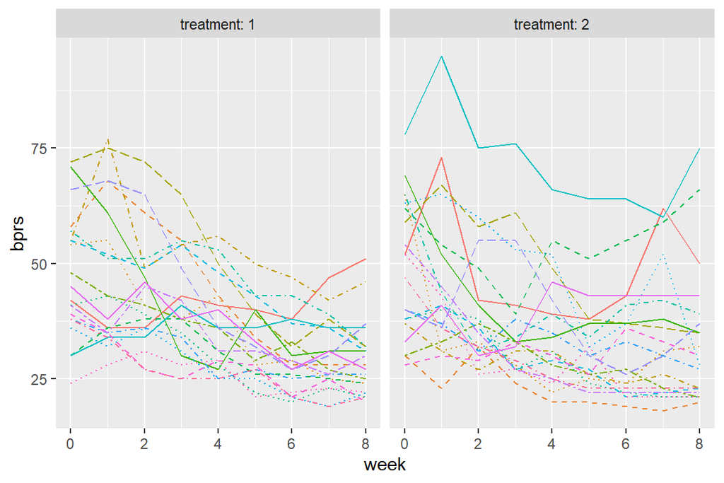

```r
# Plot the BPRSL data

library(ggplot2)
library(GGally)
ggplot(BPRSL, aes(x = week, y = bprs, linetype = subject, color = subject)) +
  geom_line() +
  scale_linetype_manual(values = rep(1:10, times=4)) +
  facet_grid(.~treatment, labeller = label_both) +
  theme(legend.position = "none")
```

```r
   scale_y_continuous(limits = c(min(BPRSL$bprs), max(BPRSL$bprs)))
```

```
## <ScaleContinuousPosition>
##  Range:
##  Limits:   18 --   95
```

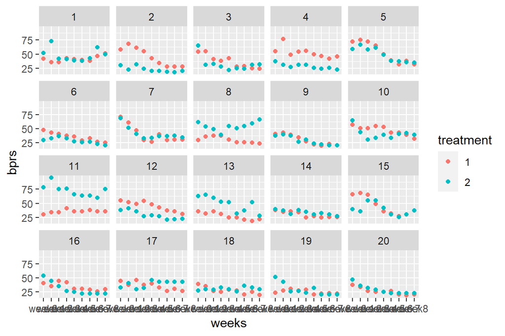

```r
ggplot(BPRSL, aes(x = weeks, y = bprs, color = treatment))+
  geom_point()+facet_wrap(~ subject)
```

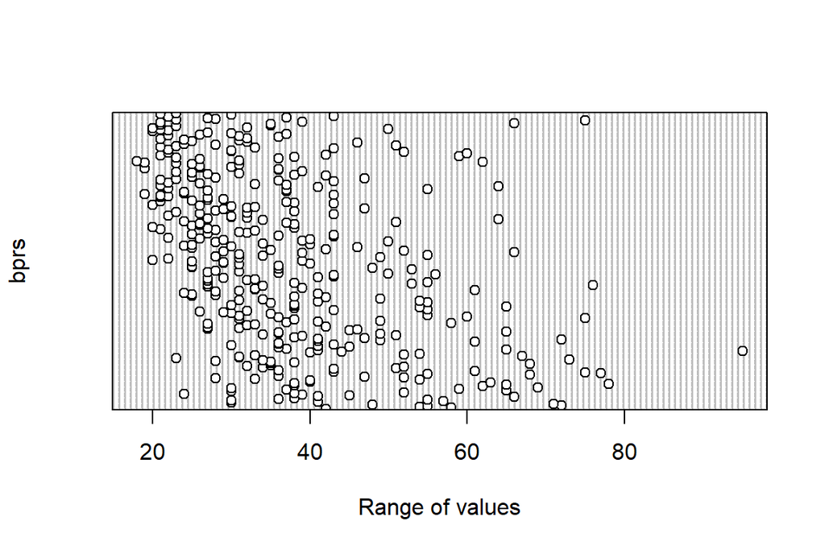

```r
#dotchart to identify outlier
dotchart(BPRSL$bprs, xlab = "Range of values", ylab = "bprs")
```

From this line graph, we can say that on average both treatments have negative relationship with bprs, which indicates that application of both treatment may lower the bprs, although in subjects bprs became in original level at the end of 8th week. It is also observable that those had higher initial bprs, their bprs were always higher throughout the treatment period. Additionally in treatment 2 one subject is showing much higher bprs than the all other subject.

To become sure about the outlier I did the dotchart, and it seems this is a outlier. I will remove this outlier and then will construct the model with the BPRS data without outlier.

## Linear regression model:

Ignoring the repeated nature of the data: bprs is the response variable and week and treatment are the explanatory variables.

```r
#removing outlier

BPRSL1 <- BPRSL[-c(71),]
dim(BPRSL1)
```

```
## [1] 359   5
```

```r
# create a regression model RATS_reg
BPRS_reg <- lm(bprs ~ treatment + week, data = BPRSL1)
summary(BPRS_reg)
```

```
##
## Call:
## lm(formula = bprs ~ treatment + week, data = BPRSL1)
##
## Residuals:
##     Min      1Q  Median      3Q     Max
## -22.200  -8.621  -3.284   7.110  46.165
##
## Coefficients:
##             Estimate Std. Error t value Pr(>|t|)
## (Intercept)  46.2003     1.3380  34.530   <2e-16 ***
## treatment2    0.2905     1.2762   0.228     0.82
## week         -2.2070     0.2473  -8.926   <2e-16 ***
## ---
## Signif. codes:  0 '***' 0.001 '**' 0.01 '*' 0.05 '.' 0.1 ' ' 1
##
## Residual standard error: 12.09 on 356 degrees of freedom
## Multiple R-squared:  0.183,  Adjusted R-squared:  0.1784
## F-statistic: 39.86 on 2 and 356 DF,  p-value: 2.398e-16
```

```r
#Checking estimated residual variance
summary(BPRS_reg)$sigma
```

```
## [1] 12.09
```

From this independent model we can see that the treatment 1 and week is statistically significant but treatment 2 does not significantly differ than the treatment 1.The estimated residual variance (sigma) of this model is 12.09, which is not that much high. The independence assumption of this model is highly unlikely.

## The random intercept model

Fitting a random intercept model allows the linear regression fit for each subject to differ in *intercept* from other subjects.

```r
# access library lme4
library(lme4)
# Create a random intercept model
BPRS_ref <- lmer(bprs ~ week + treatment + (1 | subject), data = BPRSL1, REML = FALSE)

# Print the summary of the model
summary(BPRS_ref)
```

```
## Linear mixed model fit by maximum likelihood  ['lmerMod']
## Formula: bprs ~ week + treatment + (1 | subject)
##    Data: BPRSL1
##
##      AIC      BIC   logLik deviance df.resid
##   2729.1   2748.5  -1359.5   2719.1      354
##
## Scaled residuals:
##     Min      1Q  Median      3Q     Max
## -2.8967 -0.6803 -0.1429  0.4911  3.3166
##
## Random effects:
##  Groups   Name        Variance Std.Dev.
##  subject  (Intercept)  44.37    6.661
##  Residual             100.94   10.047
## Number of obs: 359, groups:  subject, 20
##
## Fixed effects:
##             Estimate Std. Error t value
## (Intercept)  46.2651     1.8587  24.892
## week         -2.2232     0.2055 -10.819
## treatment2    0.3625     1.0606   0.342
##
## Correlation of Fixed Effects:
##            (Intr) week
## week       -0.442
## treatment2 -0.283 -0.003
```

## Random inetercept and random slope model

Now we can move on to fit the random intercept and random slope model to the BPRS data. Fitting a random intercept and random slope model allows the linear regression fits for each individual to differ in intercept but also in slope. This way it is possible to account for the individual differences in the mens’ bprs level, but also the effect of time.

```r
# create a random intercept and random slope model
library(lme4)
BPRS_ref1 <- lmer(bprs ~ week + treatment + (week | subject), data = BPRSL1, REML = FALSE)

# print a summary of the model
summary(BPRS_ref1)
```

```
## Linear mixed model fit by maximum likelihood  ['lmerMod']
## Formula: bprs ~ week + treatment + (week | subject)
##    Data: BPRSL1
##
##      AIC      BIC   logLik deviance df.resid
##   2722.3   2749.5  -1354.2   2708.3      352
##
## Scaled residuals:
##     Min      1Q  Median      3Q     Max
## -2.4231 -0.6395 -0.0738  0.5450  3.1933
##
## Random effects:
##  Groups   Name        Variance Std.Dev. Corr
##  subject  (Intercept) 60.479   7.777
##           week         1.193   1.092    -0.52
##  Residual             92.602   9.623
## Number of obs: 359, groups:  subject, 20
##
## Fixed effects:
##             Estimate Std. Error t value
## (Intercept)  46.2432     2.0392  22.677
## week         -2.2178     0.3136  -7.071
## treatment2    0.3382     1.0159   0.333
##
## Correlation of Fixed Effects:
##            (Intr) week
## week       -0.585
## treatment2 -0.247 -0.002
```

```r
# perform an ANOVA test on the two models
anova(BPRS_ref1, BPRS_ref)
```

```
## Data: BPRSL1
## Models:
## BPRS_ref: bprs ~ week + treatment + (1 | subject)
## BPRS_ref1: bprs ~ week + treatment + (week | subject)
##           npar    AIC    BIC  logLik deviance  Chisq Df Pr(>Chisq)
## BPRS_ref     5 2729.1 2748.5 -1359.5   2719.1
## BPRS_ref1    7 2722.3 2749.5 -1354.2   2708.3 10.748  2   0.004635 **
## ---
## Signif. codes:  0 '***' 0.001 '**' 0.01 '*' 0.05 '.' 0.1 ' ' 1
```

```r
AIC(BPRS_reg, BPRS_ref, BPRS_ref1)
```

```
##           df      AIC
## BPRS_reg   4 2813.313
## BPRS_ref   5 2729.093
## BPRS_ref1  7 2722.345
```

The results of this random intercept and random slope model for the fixed effects are very similar to those in random intercept model, but the likelihood ratio test for the random intercept model versus the random intercept and slope model gives a chi-squared statistic of 10.7 with 2 degrees of freedom (DF) and the associated p-value is smaller at 95% confidence interval. The AIC value of the BPRS_ref1 model is also smaller than previous model but much smaller than the regression model. Therefore,it seems that random intercept and slope model provides a better fit for this dataset.

## Random Intercept and Random Slope Model with interaction

Finally, we can fit a random intercept and slope model that allows for a treatment × week interaction.

```r
library(lme4)
BPRS_ref2 <- lmer(bprs ~ treatment * week + (week|subject), data = BPRSL1, REML = FALSE)
summary(BPRS_ref2)
```

```
## Linear mixed model fit by maximum likelihood  ['lmerMod']
## Formula: bprs ~ treatment * week + (week | subject)
##    Data: BPRSL1
##
##      AIC      BIC   logLik deviance df.resid
##   2719.9   2751.0  -1352.0   2703.9      351
##
## Scaled residuals:
##      Min       1Q   Median       3Q      Max
## -2.59132 -0.64087 -0.08802  0.54783  3.08637
##
## Random effects:
##  Groups   Name        Variance Std.Dev. Corr
##  subject  (Intercept) 60.618   7.786
##           week         1.211   1.101    -0.52
##  Residual             91.318   9.556
## Number of obs: 359, groups:  subject, 20
##
## Fixed effects:
##                 Estimate Std. Error t value
## (Intercept)      47.8856     2.1808  21.958
## treatment2       -2.9684     1.8640  -1.593
## week             -2.6283     0.3697  -7.110
## treatment2:week   0.8247     0.3909   2.110
##
## Correlation of Fixed Effects:
##             (Intr) trtmn2 week
## treatment2  -0.424
## week        -0.653  0.442
## tretmnt2:wk  0.357 -0.841 -0.527
```

```r
anova(BPRS_ref2, BPRS_ref1)
```

```
## Data: BPRSL1
## Models:
## BPRS_ref1: bprs ~ week + treatment + (week | subject)
## BPRS_ref2: bprs ~ treatment * week + (week | subject)
##           npar    AIC    BIC  logLik deviance  Chisq Df Pr(>Chisq)
## BPRS_ref1    7 2722.3 2749.5 -1354.2   2708.3
## BPRS_ref2    8 2719.9 2751.0 -1352.0   2703.9 4.4185  1    0.03555 *
## ---
## Signif. codes:  0 '***' 0.001 '**' 0.01 '*' 0.05 '.' 0.1 ' ' 1
```

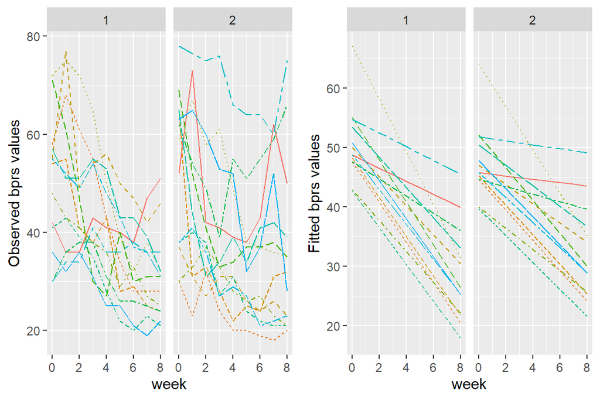

```r
# Adding fitted value to the BPRSL data frame
BPRSL1['fitted'] <- fitted(BPRS_ref2)

# draw the plot of BPRSL1 with the observed and fitted bprs values
P1 <- ggplot(BPRSL1, aes(x = week, y = bprs, linetype = subject,colour = subject)) + geom_line() +
  facet_grid(.~ treatment)+theme(legend.position = "none")+
  ylab("Observed bprs values")

P2 <- ggplot(BPRSL1, aes(x = week, y = fitted, linetype = subject,colour = subject)) + geom_line() +ylab("Fitted bprs values")+
  facet_grid(.~ treatment)+theme(legend.position = "none")

library(ggpubr)
ggarrange(P1, P2)
```

In this model inaddtion to treatment 1 and week, interaction of treatment2 and week is also significant. Here the q square value is 4.4 which is smaller than the previous model. p value is also showing that BPRS_ref2 model is significantly different than the BPRS_ref1. Additionally, lower AIC value of the model BPRS_ref2 indicates the better fitness of the model.

This graph is showing that how well the model fitted the bprs values compared to the observed values.